# Applied Regression Analysis Week 2

Pashakhin Sergey

Saturday, April 04, 2015

```r
setwd("~/applregress")
data <- read.csv("week2-HW-data.csv")
library(ggplot2)
```

## Exercise One:

Generate scatter diagrams for each of the following variable pairs: SBP (Y) vs. QUET (X) SBP (Y) vs. SMK (X) QUET (Y) vs. AGE (X) SBP (Y) vs. AGE (X)

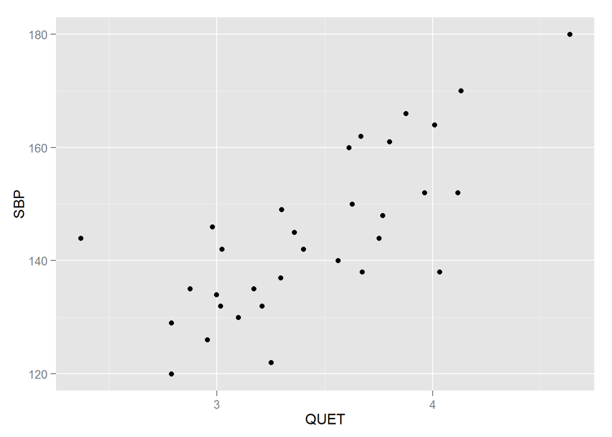

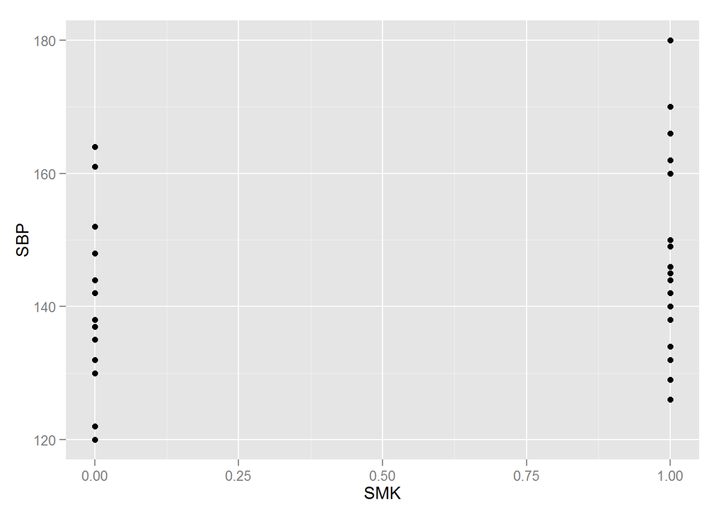

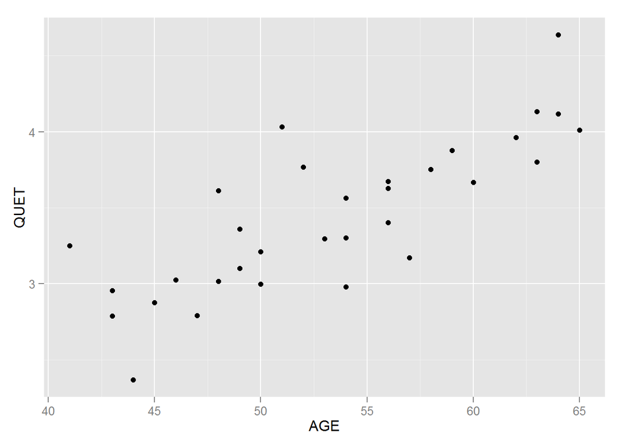

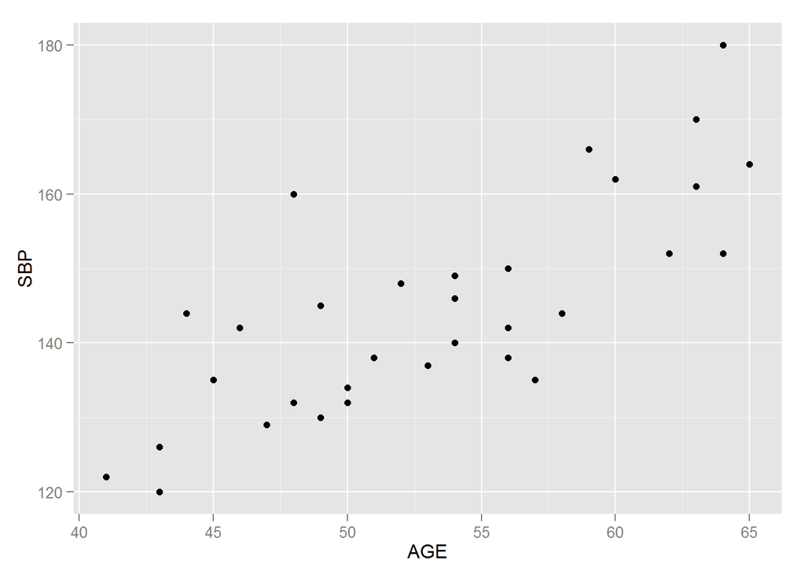

## Exercise Two:

Sketch a line Using scatter diagrams #1, #3, and #4 that you generated above, use paper and pencil to roughly sketch a line that fits the data reasonably well. Use the homework forum to share your sketches and comment on the relationships described.

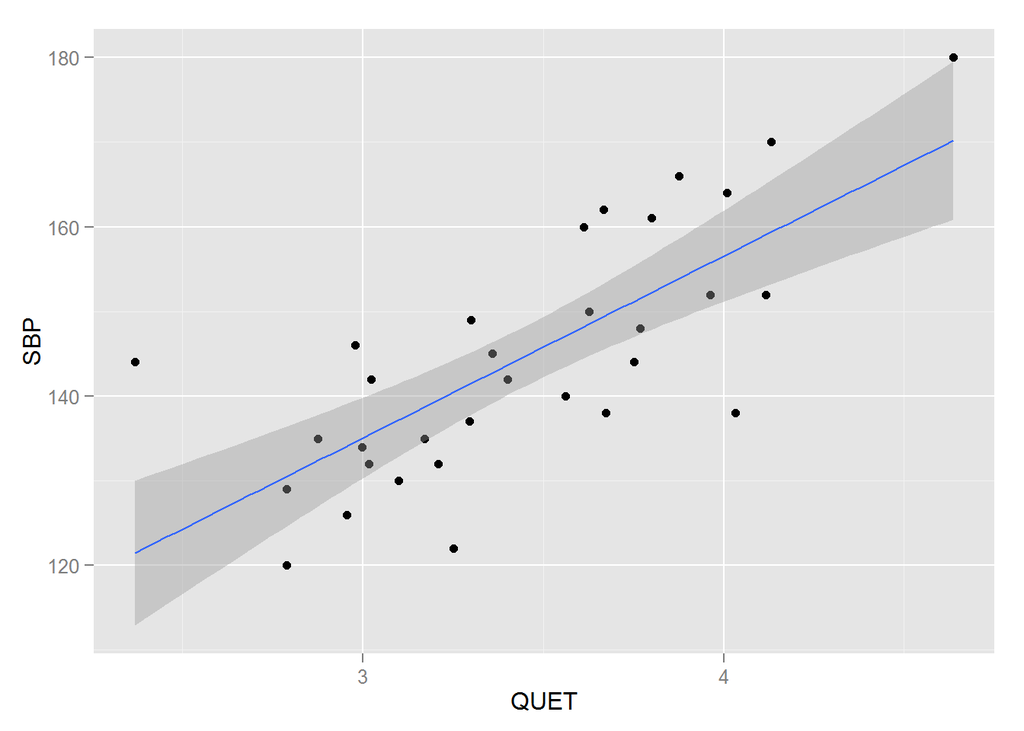

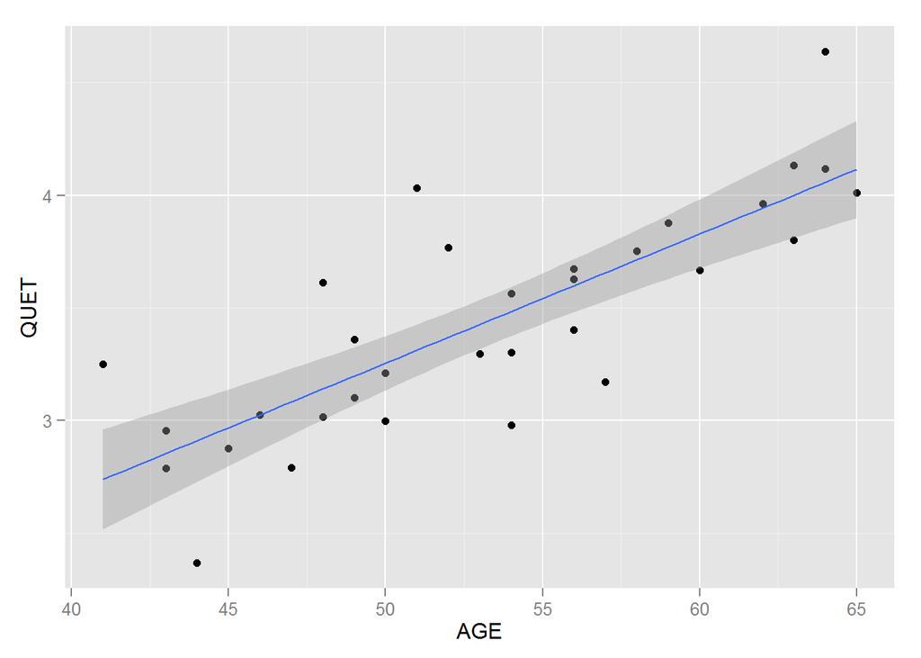

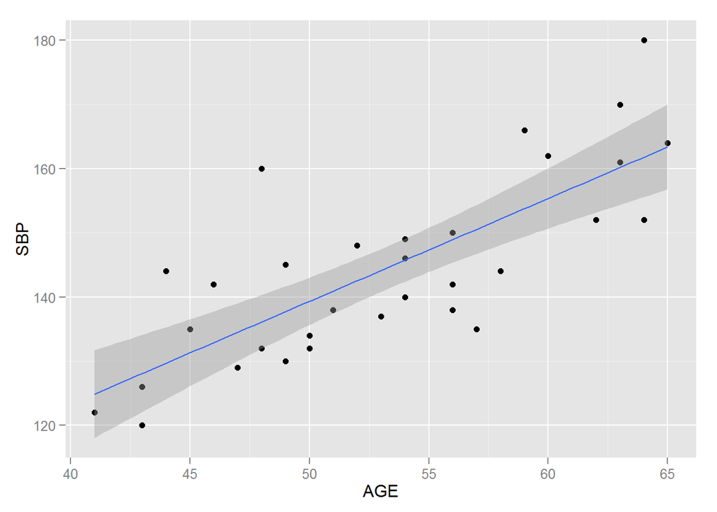

## Exercise Three:

Comparing Blood Pressure with Smoking History

1. Determine the least-squares estimates of slope β1 and intercept β0 for the straight-line regression of SBP (Y) on SMK (X).
2. Compare the value of β^0 with the mean SBP for nonsmokers. Compare the value of β<sup>0+β</sup>1 with the mean SBP for smokers. Use the homework forum to explain and share the results of these comparisons.
3. Test the hypothesis that the true slope β1 is 0.
4. Is the test in question (3) equivalent to the usual two-sample t test for the equality of two population means assuming equal but unknown variances? Demonstrate your answer numerically and share your findings in the homework forum.

```r
## 1
ex31 <- lm(SBP ~ SMK, data=data)
summary(ex31)
```

```
##
## Call:
## lm(formula = SBP ~ SMK, data = data)
##
## Residuals:
##     Min      1Q  Median      3Q     Max
## -21.824  -9.056  -2.812  11.200  32.176
##
## Coefficients:
##             Estimate Std. Error t value Pr(>|t|)
## (Intercept)  140.800      3.661  38.454   <2e-16 ***
## SMK            7.024      5.023   1.398    0.172
## ---
## Signif. codes:  0 '***' 0.001 '**' 0.01 '*' 0.05 '.' 0.1 ' ' 1
##
## Residual standard error: 14.18 on 30 degrees of freedom
## Multiple R-squared:  0.06117,    Adjusted R-squared:  0.02988
## F-statistic: 1.955 on 1 and 30 DF,  p-value: 0.1723
```

```r
## 2
nonsmokers <- subset(data, SMK == 0)
mean(nonsmokers$SBP)
```

```
## [1] 140.8
```

```r
summary(ex31)$coefficients[1]
```

```
## [1] 140.8
```

```r
summary(ex31)$coefficients[1] + summary(ex31)$coefficients[2]
```

```
## [1] 147.8235
```

```r
smokers <- subset(data, SMK == 1)
mean(smokers$SBP)
```

```
## [1] 147.8235
```

```r
## 3
t.test(SBP ~ SMK, data=data)
```

```
##
##  Welch Two Sample t-test
##
## data:  SBP by SMK
## t = -1.4129, df = 29.963, p-value = 0.168
## alternative hypothesis: true difference in means is not equal to 0
## 95 percent confidence interval:
##  -17.17585   3.12879
## sample estimates:
## mean in group 0 mean in group 1
##        140.8000        147.8235
```

```r
## 4
t.test(SBP ~ SMK, data=data, var.equal=T)
```

```
##
##  Two Sample t-test
##
## data:  SBP by SMK
## t = -1.3981, df = 30, p-value = 0.1723
## alternative hypothesis: true difference in means is not equal to 0
## 95 percent confidence interval:
##  -17.282882   3.235823
## sample estimates:
## mean in group 0 mean in group 1
##        140.8000        147.8235
```

## Exercise Four:

Comparing Blood Pressure with Body Size

1. Determine the least-squares estimates of slope and intercept for the straight-line regression of SBP (Y) on QUET (X).
2. Sketch the estimated regression line on the scatter diagram involving SBP and QUET.
3. Test the hypothesis of zero slope.
4. Find a 95% confidence interval for μy|x¯.
5. Calculate 95% prediction bands.
6. Based on the above, would you conclude that blood pressure increases as body size increases? Share your explanation and reasoning in the homework forum.
7. Are any of the assumptions for straight-line regression clearly not satisfied in this example? Explain in the homework forum.

```r
## 1
ex32 <- lm(SBP ~ QUET, data=data)
summary(ex32)
```

```
##
## Call:
## lm(formula = SBP ~ QUET, data = data)
##
## Residuals:
##     Min      1Q  Median      3Q     Max
## -19.231  -7.145  -1.604   7.798  22.531
##
## Coefficients:
##             Estimate Std. Error t value Pr(>|t|)
## (Intercept)   70.576     12.322   5.728 2.99e-06 ***
## QUET          21.492      3.545   6.062 1.17e-06 ***
## ---
## Signif. codes:  0 '***' 0.001 '**' 0.01 '*' 0.05 '.' 0.1 ' ' 1
##
## Residual standard error: 9.812 on 30 degrees of freedom
## Multiple R-squared:  0.5506, Adjusted R-squared:  0.5356
## F-statistic: 36.75 on 1 and 30 DF,  p-value: 1.172e-06
```

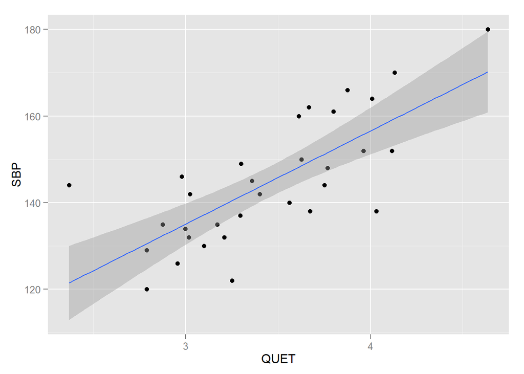

```r
## 2
qplot(QUET, SBP, data=data) + geom_smooth(method=lm)
```

```r
## 3
summary(ex32)  # The part I am confused with
```

```
##
## Call:
## lm(formula = SBP ~ QUET, data = data)
##
## Residuals:
##     Min      1Q  Median      3Q     Max
## -19.231  -7.145  -1.604   7.798  22.531
##
## Coefficients:
##             Estimate Std. Error t value Pr(>|t|)
## (Intercept)   70.576     12.322   5.728 2.99e-06 ***
## QUET          21.492      3.545   6.062 1.17e-06 ***
## ---
## Signif. codes:  0 '***' 0.001 '**' 0.01 '*' 0.05 '.' 0.1 ' ' 1
##
## Residual standard error: 9.812 on 30 degrees of freedom
## Multiple R-squared:  0.5506, Adjusted R-squared:  0.5356
## F-statistic: 36.75 on 1 and 30 DF,  p-value: 1.172e-06
```

```r
## 4
newdata <- data.frame(QUET=data$QUET)
summary(predict(ex32, newdata=newdata, interval="confidence"))
```

```
##       fit             lwr             upr
##  Min.   :121.5   Min.   :112.9   Min.   :130.0
##  1st Qu.:135.5   1st Qu.:130.9   1st Qu.:140.2
##  Median :143.2   Median :139.7   Median :146.8
##  Mean   :144.5   Mean   :139.7   Mean   :149.4
##  3rd Qu.:151.7   3rd Qu.:147.4   3rd Qu.:156.0
##  Max.   :170.2   Max.   :160.9   Max.   :179.6
```

```r
## 5
summary(predict(ex32, newdata=newdata, interval="prediction"))
```

```
##       fit             lwr              upr
##  Min.   :121.5   Min.   : 99.69   Min.   :143.3
##  1st Qu.:135.5   1st Qu.:114.96   1st Qu.:156.1
##  Median :143.2   Median :122.88   Median :163.6
##  Mean   :144.5   Mean   :123.88   Mean   :165.2
##  3rd Qu.:151.7   3rd Qu.:131.24   3rd Qu.:172.2
##  Max.   :170.2   Max.   :148.12   Max.   :192.3
```

### 6

Yes.

### 7

We could plot residuals and do diagnostic plots but it is beyond this week’s materials. So, I would just say: no.